# SIMULACIÓN ESTADÍSTICA

Paúl Zurita & Ana Córdova

Mayo 13, 2019

[figure not shown]

`NOTA: Haga click sobre la imagen para visualizar la pantalla interactiva`.

### **PRÓLOGO**

El presente texto es el resultado de la experiencia docente de los autores y se aspira que se constituya en una herramienta de consulta en el tema de Simulación Estadística, con el apoyo de software libre **R**.

La Modelación Matemática y la Simulación son técnicas fundamentales en el campo de la Ingeniería y de las Ciencias en general, más aún en la actualidad en que se dispone de poderosas computadoras y de software cada vez más sofisticado que ayudan a resolver problemas complejos y optimizar recursos.

Es un libro de nivel introductorio al tema dirigido a investigadores, ingenieros y estudiantes de pregrado de las carreras de Ingeniería, así como estudiantes de posgrado en áreas técnicas. Los prerrequisitos necesarios para una mejor comprensión del texto son conocimientos de Estadística Descriptiva y de Programación.

La redacción del libro se ejecutó enteramente con `R Markdown` en el ambiente `RStudio versión 1.0.136`, y para toda la codificación en **R** se recomienda utilizar la versión `3.3.1` en adelante.

La organización del libro es la siguiente: El `Capítulo 1` cubre los conceptos principales de la Estadística básica, prerrequisito fundamental para comprender mejor la técnica de Simulación. Para una mejor explicación, las definiciones se acompañan de ejemplos ilustrativos que describen los momentos de los datos tanto analíticamente como gráficamente.

En el `Capítulo 2` se introduce el concepto de variable aleatoria y sus respectivas distribuciones de probabilidad tanto discretas como continuas. Se describen distribuciones básicas de uso frecuente acompañadas de la respectiva codificación en **R**.

El `Capítulo 3` comprende los principios básicos de las Pruebas de Bondad de Ajuste. Se detalla la prueba Chi- cuadrado para el caso de distribuciones discretas y la prueba de Kolmogorov-Smirnov para el caso de distribuciones continuas.

En el `Capítulo 4` se explican los algoritmos congruentes para generar números aleatorios, así como los métodos para generar variables aleatorias a partir de las distribuciones de probabilidad tanto discretas como continuas. Se han propuesto varios ejemplos que refuerzan los conceptos planteados acompañados siempre de su respectiva codificación en **R**.

Se justifica la publicación de esta obra en virtud de la escasa bibliografía existente sobre el tema de Simulación Estadística en nuestro medio, sobre todo en español. Además, por tratarse de un libro virtual, tiene la ventaja de ser un `libro interactivo`, que le permite al usuario profundizar los conceptos teóricos a través de gráficas animadas.

Quisiera dedicar este trabajo y el esfuerzo empleado en su realización a `Dios:` camino, verdad y vida. A la `Madre de Dios` y Madre nuestra por su intervención directa en mi vida. También con mucho amor lo dedico a `Any, Pedrito, Sari, Joaquín y a mi Padre Pedro Pablo`.

> *AUTORES:*
- **PAÚL HERNÁN ZURITA LLERENA:** Docente Investigador de la Pontificia Universidad Católica del Ecuador sede Ambato.

  ```
  -Ingeniero Civil
  -Magíster en Investigación Operativa
  -Master en Riesgo Financiero
  ```

- **ANA CONSUELO CÓRDOVA PACHECO:** Docente Investigadora de la Universidad Técnica de Amabato.

  ```
  -Ingeniera Comercial
  -Magíster en Gerencia Financiera Empresarial
  ```

[interactive chart not shown]

## **CAPÍTULO I: ESTADÍSTICA BÁSICA PARA SIMULACIÓN**

### **INTRODUCCIÓN**

Se presenta en este capítulo de manera resumida los requerimientos mínimos necesarios de la estadística básica que ayudarán a comprender mejor la técnica de `simulación` y plantear `modelos` de tal manera que se puedan crear escenarios para un posterior análisis.

Se inicia con un análisis descriptivo de los datos acompañado de su representación gráfica que ayudará a visualizar mejor los resultados y enriquecer la interpretación para la toma de decisiones.

Para descargarse el programa **R** puede ingresar en el siguiente enlace (http://www.r-project.org/).

Para descargarse el programa **RStudio** puede ingresar en el siguiente enlace (http://www.rstudio.com/).

El presente trabajo fue escrito en **R Markdown**. `Markdown` nos permite escribir documentos en *HTML*, *PDF*, y *MS Word*. Para consulta de R Markdown se puede ingresar al siguiente enlace (Xie, 2015): (http://rmarkdown.rstudio.com).

A continuación se plantea un primer ejemplo con el que se irán desarrollando algunas definiciones y realizando los respectivos cálculos.

> **EJEMPLO 1.1:**

> En una institución financiera el número de créditos concedidos en las diez últimas semanas se presentan a continuación:

| Semana | 1 | 2 | 3 | 4 | 5 | 6 | 7 | 8 | 9 | 10 |
| --- | --- | --- | --- | --- | --- | --- | --- | --- | --- | --- |
| Número | 12 | 15 | 10 | 7 | 21 | 33 | 23 | 12 | 8 | 12 |

Como se puede observar, se trata de un conjunto de `datos discretos` con los cuales se va a calcular la `estadística descriptiva` básica.

[figure not shown]

`NOTA: Haga click sobre la imagen para visualizar la pantalla interactiva`.

### **MEDIDAS DE TENDENCIA CENTRAL.**

Consideradas como el `primer momento` de los datos, reflejan las características del *centro* de los datos (Triola, 2013). Estas medidas se las puede dividir en tres clases (Caro, 2013):

```
    -   de tamaño          (la media).
    -   de posición        (la mediana).
    -   y de frecuencia    (la moda).
```

- **MEDIA:** La media es el promedio de los datos. Es la medida de tendencia central más conocida y utilizada, sin embargo, su principal desventaja es que resulta ser muy sensible a cambios de sus valores extremos (Martínez Bencardino, 2012).

$$\bar{x}=\frac{\sum x_i}{n}$$

- **MEDIANA:** Es el *punto medio* de una serie ordenada de **n** datos. Esta medida no es sensible a cambios de los valores (Martínez Bencardino, 2012). Los pasos a seguir para determinar la mediana son:

  ```
  - Ordenar los datos en forma ascendente: 7, 8, 10, 12, 12, 12, 15, 21, 23, 33
  - Si n es impar la mediana es el número de la mitad del conjunto ordenado.
  - Si n es par se debe promediar los dos valores intermedios del conjunto ordenado.
  ```

- **MODA:** Es el valor más frecuente dentro de un grupo de datos. Una distribución puede tener `dos modas`, en este caso se dice que se trata de una distribución `Bimodal`. Si existieran más de dos modas, se dice que se trata de una distribución `Multimodal` (Martínez Bencardino, 2012).

### **PERCENTILES Y CUARTILES**

Se define el percentil `Q%` de una muestra, como el valor del dato que ocupa el lugar $(n)(Q) / 100$ pero redondeado hacia arriba (Castillo, 2013). Los percentiles subdividen el conjunto de **n** datos de acuerdo con la proporción de frecuencias observadas. Mientras que la `mediana` divide a la distribución en dos mitades, `los cuartiles` la dividen en cuatro cuartos. A los percentiles 25% y 75% se les conoce como primer cuartil y tercer cuartil respectivamente. Si se cuenta con pocos datos los percentiles no serán de utilidad, los percentiles serán útiles mientras más datos tenga la muestra (González Támara, 2013, consultado 03/04/2017).

Mediante el siguiente codigo en **R**, con el comando `summary` se obtiene el mínimo, el primer cuartil, la mediana, la media, el tercer cuartil y el valor máximo de los datos (Krijnen, 2009):

```r
creditos<-c(12,15,10,7,21,33,23,12,8,12)
creditos
```

```
##  [1] 12 15 10  7 21 33 23 12  8 12
```

```r
summary(creditos)
```

```
##    Min. 1st Qu.  Median    Mean 3rd Qu.    Max.
##     7.0    10.5    12.0    15.3    19.5    33.0
```

Como se puede observar el comando `summary` no proporciona la `moda` de los datos, por ello se debe instalar el paquete `modeest` con la instrucción `install.packages("modeest")`, luego de instalar el programa se lo debe cargar a memoria con la instrucción `library(modeest)` y utilizar el comando `mfv` para determinar la moda de los datos:

```r
library(modeest)
```

```r
mfv(creditos)
```

```
## [1] 12
```

### **DIAGRAMA DE CAJA**

Para graficar el diagrama de caja se debe ordenar los datos en forma ascendente, este diagrama resume los datos mediante una caja central que agrupa el 50% de los datos. El 25% de los datos más grandes se encuentra arriba de la caja central, mientras que el 25% de los datos más pequeños está por debajo de la caja central (Castillo, 2013). Los límites de la caja son el primer cuartil en la parte inferior y el tercer cuartil en la parte superior.

Una manera alternativa de analizar la dispersión de los datos, que puede resultar muy práctica sobre todo en el caso en que la distribución sea asimétrica o en presencia de datos atípicos, es el `rango intercuartílico`.

**El rango intercuartílico (RIC):** Como ya se sabe, la mediana representa el punto que divide el conjunto de datos en dos partes del mismo tamaño. Los cuartiles son los puntos que dividen el conjunto de datos en cuatro partes del mismo tamaño. El primer cuartil Q1 deja el 25% de los datos ordenados a su izquierda, y el otro 75% a su derecha, mientras que el tercer cuartil Q3 deja el 75% de los datos ordenados a su izquierda, y el otro 25% a su derecha. De esta manera el par (Q1, Q3) proporciona información acerca de la dispersión de los datos, de tal manera que cuanto más alejados estén los cuartiles, más dispersos estarán los datos.

Se calcula el rango intercuartílico RIC como la diferencia entre Q3 y Q1.

$$RIC = Q3 - Q1$$

El RIC se lo utiliza para detectar datos atípicos, considerados como atípicos los datos menores de $Q1 - 1,5 × RIC$, o mayores de $Q3 + 1,5 × RIC$, estos límites se conocen como bigotes (Montgomery, 2010).

El diagrama de caja constituye una representación gráfica de los datos que permite visualizar la tendencia central, la dispersión y la presencia posible de datos *atípicos*. Un dato atípico (outlier) es una observación extrema con respecto al resto de los datos. Examinar posibles datos atípicos ayuda a identificar distribuciones sesgadas o errores en el ingreso de los datos (Diez et al., 2014).

Estos diagramas son muy útiles para comparar dos o más conjuntos de datos, y se constituye en un gráfico muy interesante que resume los datos mediante cinco números: el mínimo, los tres cuartiles y el máximo (Lacourly, 2010, consultado 03/04/2017).

A continuación se presenta el código que nos permite obtener el `diagrama de caja` de los datos de créditos, junto con un diagrama de barras y de dispersión (Peng, 2015):

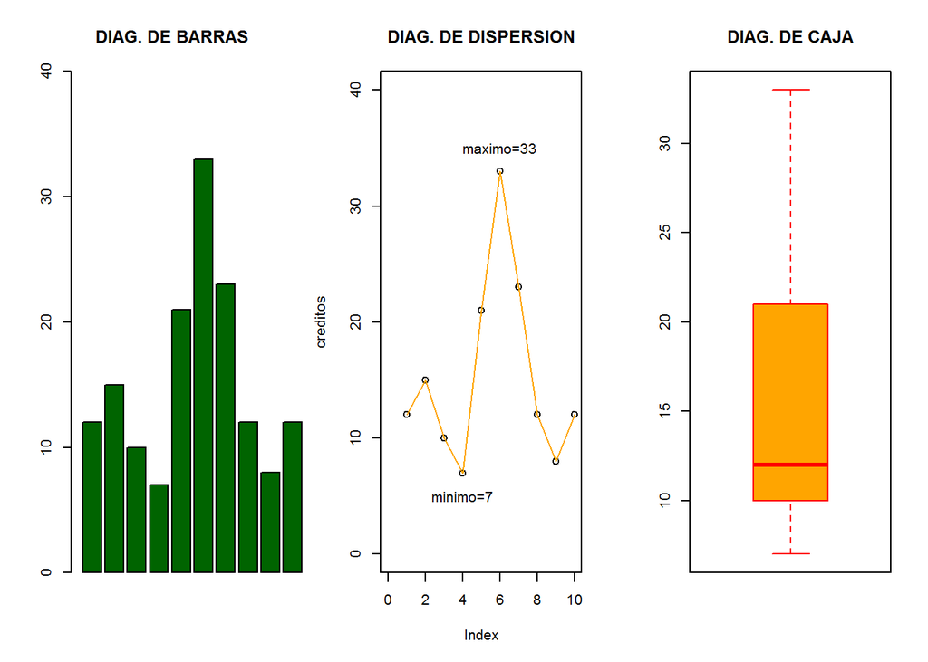

Fig. 1.1 Diagramas de los datos de créditos

```r
par(mfrow=c(1,3))
barplot(creditos, xlim=range(0:10),ylim=range(0:40),main="DIAG. DE BARRAS",col="darkgreen")
plot(creditos,xlim=range(0:10),ylim=range(0:40),main="DIAG. DE DISPERSION")
text(6,35,label="maximo=33")
text(4,5,label="minimo=7")
lines(creditos,col="orange")
boxplot(creditos, horizontal = FALSE, border=rainbow(1), main="DIAG. DE CAJA", col="orange")
```

**CONCLUSIÓN**

Se puede observar que no existen datos *atípicos*, pero los datos tienen asimetría *positiva* lo que se refleja en el diagrama de caja, además el máximo número de créditos otorgados por la institución es de 33 mientras que el mínimo es de 7 en una determinada semana, lo que indica que hay una alta dispersión respecto al centro y que puede reflejarse en la desviación estándar.

> **NOTA:** Para el siguiente gráfico se considera que el número de créditos concedidos en las dos últimas semanas se han incrementado considerablemente con respecto a las semanas anteriores, en la semana 9 se han concedido 80 créditos y en la semana 10 se han concedido 120 créditos, con lo que los datos ahora son:

| Semana | 1 | 2 | 3 | 4 | 5 | 6 | 7 | 8 | 9 | 10 |
| --- | --- | --- | --- | --- | --- | --- | --- | --- | --- | --- |
| Número | 12 | 15 | 10 | 7 | 21 | 33 | 23 | 12 | 80 | 120 |

[figure not shown]

`NOTA: Haga click sobre la imagen para visualizar la pantalla interactiva.`

### **MEDIDAS DE DISPERSIÓN**

Las medidas de tendencia central sólo revelan una parte de la información contenida en los datos (Levin, 2010), para incrementar la confiabilidad en cuanto al análisis y conclusiones obtenidas de los datos, se debe medir la dispersión de la nube de puntos.

Las medidas de dispersión son conocidas como el `segundo momento` de los datos, donde la dispersión constituye la separación que presentan los datos entre sí con respecto al centro (Castillo, 2013). Las medidas de dispersión más conocidas son:

- **RANGO:** Es la diferencia entre el valor *máximo* y *mínimo* de un grupo de datos. Mientras mayor sea el rango, mayor será la dispersión de los datos ((Castillo, 2013).
- **VARIANZA:** Es el indicador de dispersión alrededor de la media. La varianza muestral es un estimador insesgado de la varianza poblacional, no obstante tiene una gran desventaja, las unidades de medida están elevadas al cuadrado (Triola, 2013), es por ello que se prefiere trabajar con la desviación estándar.

$$S^{2}=\frac{\sum (x_i-\bar{x})^2}{n-1}$$

- **DESVIACIÓN ESTÁNDAR:** Mide la dispersión promedio de los datos alrededor de la media, es la *raíz cuadrada* de la varianza. La desviación estándar tiene la ventaja de medir la variabilidad de los datos en las mismas unidades originales de la variable de interés (Montgomery, 2010).

### **MEDIDAS DE FORMA**

**COEFICIENTE DE ASIMETRÍA:** se conoce como el `tercer momento` de los datos. Este coeficiente mide la *asimetría* de los datos respecto a su centro. Tiene un valor de *cero* para una variable *simétrica*. Cuando el valor absoluto del coeficiente es aproximadamente mayor que *uno* podemos concluir que los datos tienen una distribución claramente *asimétrica*. Si la distribución es *unimodal* y se trata de una distribución simétrica, entonces, la media, la mediana y la moda son prácticamente iguales. Si los datos tienen asimetría *negativa* resulta que la media es menor que la mediana y esta es menor que la moda. Para el caso en que los datos tengan asimetría *positiva*, la moda es menor que la mediana y esta a su vez es menor que la media.

Cuando las frecuencias de los datos son muy altas, la distribución deja de ser simétrica. Una distribución `asimétrica` ya sea positiva o negativa puede resultar altamente `riesgosa` (Martínez Bencardino, 2012).

Para calcular el `coeficiente de asimetría` se puede utilizar la siguiente expresión, aunque existen otras fórmulas:

$$As=\frac{n}{(n-1)(n-2)}\times\sum ({\frac {x_i-\bar{x}}{s}})^3$$

**CURTOSIS:** considerada como el `cuarto momento` de los datos debido a que es una medida de la altura de la curva. La *curtosis* representa la elevación o el achatamiento de una distribución comparada con la *distribución normal*. Si la distribución es relativamente *elevada* con respecto a la normal se le denomina `leptocúrtica`, mientras que si la distribución es relativamente *plana* con respecto a la normal, se le denomina `planticúrtica`. En el caso de la distribución Normal se dice que es `mesocúrtica` (Martínez Bencardino, 2012).

Para calcular la `curtosis` se puede utilizar la siguiente expresión:

$$k=[\frac{n(n+1)}{(n-1)(n-2)(n-3)}\times\sum ({\frac {x_i-\bar{x}}{s}})^4]-\frac{3(n-1)^2}{(n-2)(n-3)}$$

Para calcular la `asimetría` y la `curtosis` en **R**, es preferible instalar el complemento `fBasics` con la instrucción `install.packages("fBasics")` y cargarlo a memoria mediante el comando `library(fBasics).`

Una vez cargado en memoria el programa, mediante la instrucción `basicStats` se calculan los estadísticos básicos de la variable analizada, en este caso la variable `créditos`.

```r
library(fBasics)
```

```r
basicStats(creditos)
```

```
##               creditos
## nobs         10.000000
## NAs           0.000000
## Minimum       7.000000
## Maximum      33.000000
## 1. Quartile  10.500000
## 3. Quartile  19.500000
## Mean         15.300000
## Median       12.000000
## Sum         153.000000
## SE Mean       2.556256
## LCL Mean      9.517347
## UCL Mean     21.082653
## Variance     65.344444
## Stdev         8.083591
## Skewness      0.940794
## Kurtosis     -0.389819
```

### **HISTOGRAMAS**

Mientras que un diagrama de puntos es una representación gráfica de cada observación y puede ser de utilidad en el caso de muestras pequeñas, un histograma es una representación gráfica de los datos agrupados en intervalos de clase (Diez et al., 2015).

Los `histogramas` son de gran ayuda al momento de tratar de entender la forma de los datos de tal manera que rápidamente se pueda determinar si existe *asimetría* ya sea positiva o negativa o los datos son simétricos. Uno de los métodos que permiten comprender la población de un vistazo es un histograma.

La organización de una gran cantidad de datos en un histograma permite comprender la población de manera objetiva, además de anticipar si se puede modelar los datos con alguna distribución de probabilidad específica. El histograma es especialmente útil para describir la forma de la distribución y proporciona una rápida representación gráfica de la densidad de los datos.

> **EJEMPLO 1.2:**

> A continuación se presentan los rendimientos diarios de una inversión durante 250 días. La base de datos se supone que se encuentra en el *escritorio* en la carpeta **MODELOS Y SIMULACION**, y se llama `datosinversiones.txt`. Los nombres de las variables se las puede visualizar mediante el comando `names()`. Se muestran las 25 primeras observaciones mediante el comando `head()`, mientras que la base de datos completa se encuentra en el anexo 1.

```r
setwd("C:/Users/Usuario/Desktop/MODELOS Y SIMULACION")
datosinversiones = read.table('datosinversiones.txt',header=TRUE)
attach(datosinversiones)
names(datosinversiones)
```

```
## [1] "DIA"         "RENDIMIENTO"
```

```r
head(datosinversiones$RENDIMIENTO, 25)
```

```
##  [1] -1.397  0.850 -0.110  0.972  0.880  0.424  1.360  0.734  0.834 -0.776
## [11] -1.694  1.617  0.383 -0.959  0.483  0.127 -0.573  1.169  1.148  0.128
## [21] -3.054 -0.536  0.604 -0.709  0.078
```

Se presenta la estadística básica de los datos mediante el comando `summary` y la representación gráfica por medio del histograma con el comando `hist` y el diagrama de caja con el comando `boxplot` (Seefeld, 2007).

```r
summary(datosinversiones$RENDIMIENTO)
```

```
##     Min.  1st Qu.   Median     Mean  3rd Qu.     Max.
## -3.05400 -0.70850  0.07600  0.04841  0.73620  2.89600
```

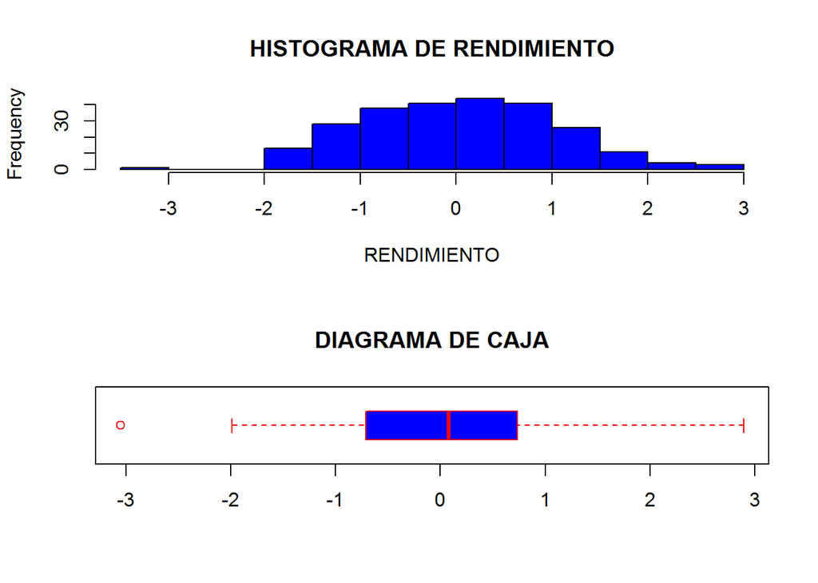

Fig. 1.2 Diagramas de los datos RENDIMIENTO

```r
par(mfcol=c(2,1))
hist(RENDIMIENTO, main="HISTOGRAMA DE RENDIMIENTO", col="blue")
boxplot(RENDIMIENTO, horizontal = TRUE, border=rainbow(1), main="DIAGRAMA DE CAJA", col="blue")
```

Un reporte más completo se obtiene con la instrucción `basicStats` del paquete `fBasics`. Es necesario instalar el paquete `fBasics` con la instrucción `install.packages("fBasics")`, luego de instalar el programa se lo debe cargar a memoria con la instrucción `library(fBasics)` y utilizar el comando `basicStats`.

```r
library(fBasics)
```

```r
basicStats(datosinversiones)
```

```
##                      DIA RENDIMIENTO
## nobs          250.000000  250.000000
## NAs             0.000000    0.000000
## Minimum         1.000000   -3.054000
## Maximum       250.000000    2.896000
## 1. Quartile    63.250000   -0.708500
## 3. Quartile   187.750000    0.736250
## Mean          125.500000    0.048408
## Median        125.500000    0.076000
## Sum         31375.000000   12.102000
## SE Mean         4.573474    0.064004
## LCL Mean      116.492374   -0.077650
## UCL Mean      134.507626    0.174466
## Variance     5229.166667    1.024131
## Stdev          72.312977    1.011993
## Skewness        0.000000    0.127741
## Kurtosis       -1.214409   -0.216254
```

### **ESTADÍSTICAS ROBUSTAS**

Se puede definir las `estadísticas robustas` como aquellas medidas para las cuales los `valores atípicos` tienen poco efecto, es decir son aquellas que no sufren casi variación a causa de variaciones en observaciones extremas (Diez et al., 2014). A continuación se presenta un resumen de tales medidas consideradas robustas:

|  | NO ROBUSTAS | ROBUSTAS |
| --- | --- | --- |
| Medidas de | Media | Mediana |
| tendencia central |  |  |
| ——————- | ————————————– | ————————————— |
| Medidas de | Desviación estándar | Rango intercuartílico RIC |
| dispersión | Rango |  |
| ——————- | ————————————– | ————————————— |
| OBSERVACIÓN | Especialmente la media y la | Las medidas robustas se recomienda |
|  | desviación estándar se pueden | utilizarlas cuando los datos son |
|  | utilizar cuando los datos son | asimétricos con observaciones |
|  | simétricos. | extremas. |
| ——————- | ————————————– | ————————————— |